# Chapter 2: Geographic data in R

Yifei Liu

8/17/2019

Prequisites

```r
library(tidyverse)
library(sf)
library(sp)
library(raster)
library(spData)
library(spDataLarge) # devtools::install_github("Nowosad/spDataLarge")
```

## 2.1 Introduction

intro fundamental geographic data mdels: vector and raster

*Defination*

- vector data model represents the world using points, lines and polygons. These have discrete, well-defined borders, meaning that vectors datset usually have a high level of precision (but not necessarily accuracy),
- The raster dataset are the basis of background images used in web-mapping and have been a vital soruce of geographic data since the orgin of aerial photography and satellte-based remote sensing devices. meaning that they are consistent over space and scalabel (many worldwide raster dataset are available)

*Application*

- vector data tends to dominate the social science because human settlements tend to have discrete borders (like map data and census data)
- Raster often dominate in enviormental science because of the reliance on remote sensing data. (PG&E company use satellite image to detech electricity grid ages)

It’s possible to conver these two dataset. This book use sf and raster packages to work with vector data and raster dataset, respectively.

## 2.2 Vector data

sf is a package providing a class system for geographic vector data.

### 2.2.1 An introuction to simple features

sf increase several core geometry types: multilinestrings, multipoint, multipolygon, geometrycollection, polygon, point, linstring.

raster data are *not* supported by sf

```r
names(world)
```

```
##  [1] "iso_a2"    "name_long" "continent" "region_un" "subregion"
##  [6] "type"      "area_km2"  "pop"       "lifeExp"   "gdpPercap"
## [11] "geom"
```

```r
class(world)
```

```
## [1] "sf"         "data.frame"
```

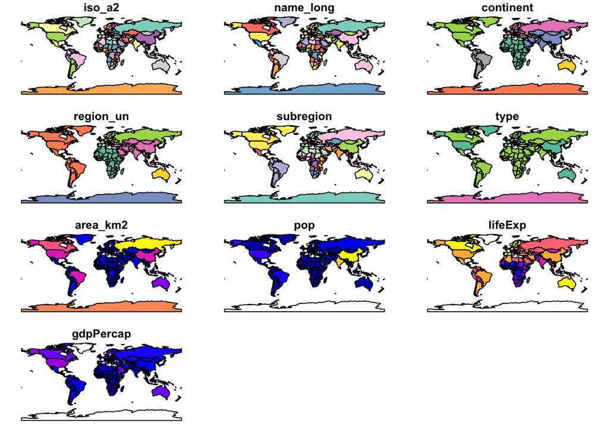

```r
plot(world, max.plot = 10)
```

```r
map(world, summary)
```

```
## $iso_a2
##    Length     Class      Mode
##       177 character character
##
## $name_long
##    Length     Class      Mode
##       177 character character
##
## $continent
##    Length     Class      Mode
##       177 character character
##
## $region_un
##    Length     Class      Mode
##       177 character character
##
## $subregion
##    Length     Class      Mode
##       177 character character
##
## $type
##    Length     Class      Mode
##       177 character character
##
## $area_km2
##     Min.  1st Qu.   Median     Mean  3rd Qu.     Max.
##     2417    46185   185004   832558   621860 17018507
##
## $pop
##      Min.   1st Qu.    Median      Mean   3rd Qu.      Max.      NA's
## 5.630e+04 3.755e+06 1.040e+07 4.282e+07 3.075e+07 1.364e+09        10
##
## $lifeExp
##    Min. 1st Qu.  Median    Mean 3rd Qu.    Max.    NA's
##   50.62   64.96   72.87   70.85   76.78   83.59      10
##
## $gdpPercap
##     Min.  1st Qu.   Median     Mean  3rd Qu.     Max.     NA's
##    597.1   3752.4  10734.1  17106.0  24232.7 120860.1       17
##
## $geom
##  MULTIPOLYGON     epsg:4326 +proj=long...
##           177             0             0
```

```r
summary(world["lifeExp"])
```

```
##     lifeExp                 geom
##  Min.   :50.62   MULTIPOLYGON :177
##  1st Qu.:64.96   epsg:4326    :  0
##  Median :72.87   +proj=long...:  0
##  Mean   :70.85
##  3rd Qu.:76.78
##  Max.   :83.59
##  NA's   :10
```

### 2.2.2 Why simpel features?

why use *sf* (simple features) when *sp* is already tried and tested?

- Faster reading and writing of data
- Enhanced plotting performance
- sf objects can be treated as data frames in most operations
- sf functions can be combined using %>% operator and worked well with *tidyverse* collection of R packages
- sf function names are relarively consistent and intuitive (all begin iwth st_)

summary: easy to use, more collaboration with core package, effciency, clarity

lot of spatial pakcages now added suppor for sf and you can also transfer sp to sf objec and vice versa

```r
world_sp = as(world, Class = "Spatial")

class(world_sp)
```

```
## [1] "SpatialPolygonsDataFrame"
## attr(,"package")
## [1] "sp"
```

```r
world_sf = st_as_sf(world_sp)
world
```

```
## Simple feature collection with 177 features and 10 fields
## geometry type:  MULTIPOLYGON
## dimension:      XY
## bbox:           xmin: -180 ymin: -90 xmax: 180 ymax: 83.64513
## epsg (SRID):    4326
## proj4string:    +proj=longlat +datum=WGS84 +no_defs
## First 10 features:
##    iso_a2        name_long     continent region_un          subregion
## 1      FJ             Fiji       Oceania   Oceania          Melanesia
## 2      TZ         Tanzania        Africa    Africa     Eastern Africa
## 3      EH   Western Sahara        Africa    Africa    Northern Africa
## 4      CA           Canada North America  Americas   Northern America
## 5      US    United States North America  Americas   Northern America
## 6      KZ       Kazakhstan          Asia      Asia       Central Asia
## 7      UZ       Uzbekistan          Asia      Asia       Central Asia
```

[output cut: 25 more lines]

```r
identical(world, world_sf)
```

```
## [1] FALSE
```

### 2.2.3 Basic map making

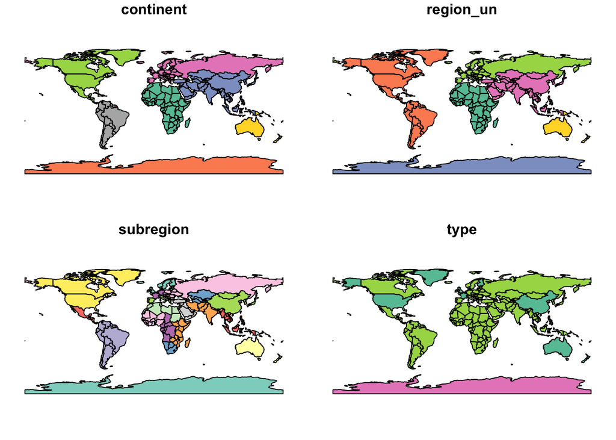

```r
plot(world[3:6])
```

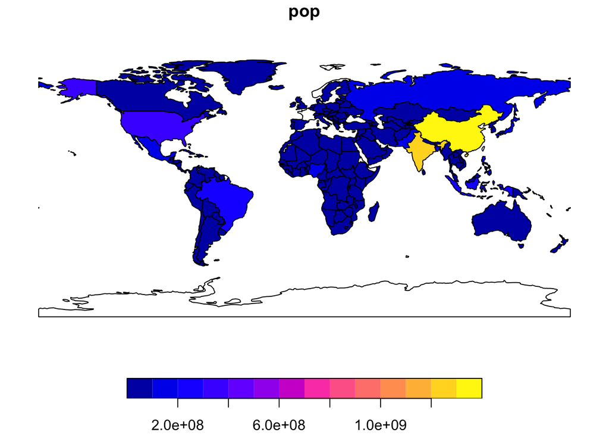

```r
plot(world["pop"])
```

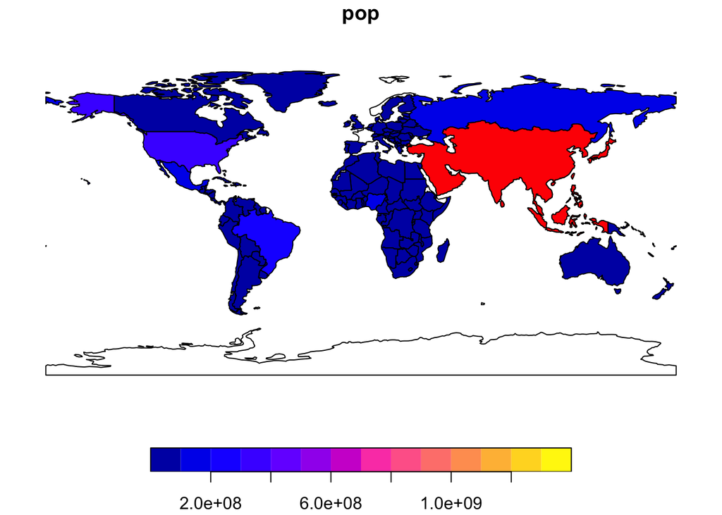

```r
asia <- world %>%
  filter(continent == "Asia") %>%
  st_union()

plot(world["pop"], reset = F)
plot(asia, add = TRUE, col = "red")
```

### 2.2.4 Base plot arguments

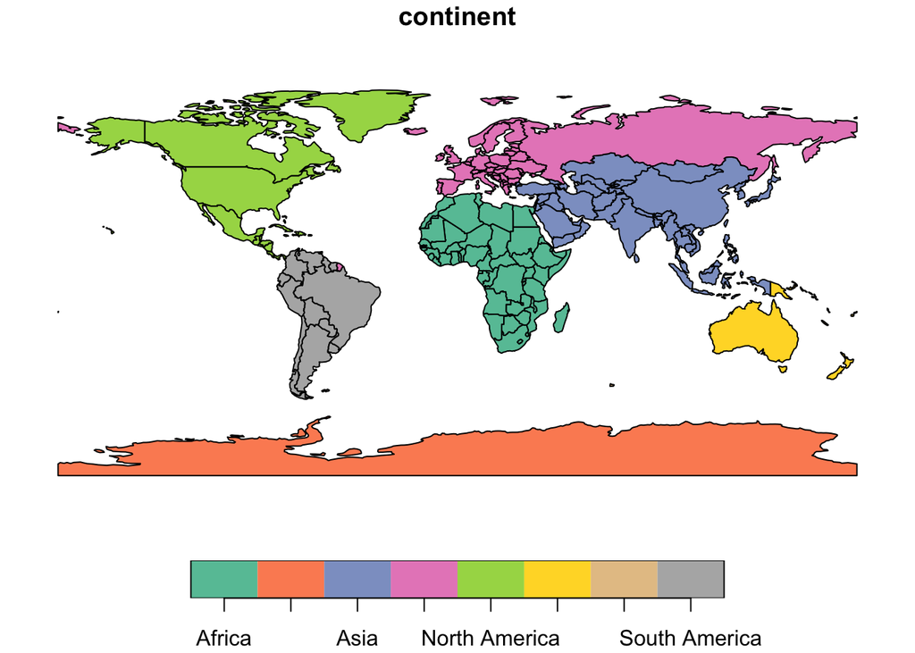

```r
plot(world["continent"])
cex = sqrt(world$pop) / 10000
world_cents = st_centroid(world, of_largest = TRUE)
plot(st_geometry(world_cents), add = TRUE, cex = cex)
```

### 2.2.6